# Statistical Analysis of League of Legends data

Regie Daquioag and Carlos Huizar

May 03, 2018

## Project Introduction

In this project we are going to explore the influences that help teams win games in League of Legends. In LoL there are various of factors that can help win the game such as getting kills and taking objectives on the map. Teams use these to obtain gold that helps make their character stronger and the winner is decided by whoever takes the opponents base first. We are going to explore the various of factors that can help win the game and decside which are the most important to focus on.

## Project Data

Data Source: https://www.kaggle.com/datasnaek/league-of-legends/data

## Data cleaning and preprocessing

This project relied heavily on categorical data so it was of the utmost importance to determine who the winner of a match will be, they winner would either be the blue team (1) or the red team (2). The main question was what data we wanted to look at and we determined that many of the data provided would not be necessary. For example, we need not care about which champions made it through the pick/ban phase and what summoner spells were used.

```r
> #Erase the season ID as it provides no statistical value for the set
> dat$seasonId = NULL
>
> #Champion Bans are set to NULL to help run the data set for efficiently
> dat$t1_ban1 = NULL
> dat$t1_ban2 = NULL
> dat$t1_ban3 = NULL
> dat$t1_ban4 = NULL
> dat$t1_ban5 = NULL
> dat$t2_ban1 = NULL
> dat$t2_ban2 = NULL
> dat$t2_ban3 = NULL
> dat$t2_ban4 = NULL
> dat$t2_ban5 = NULL
>
> #Champion ID's are set to NULL because the different champions are not always in the same game and are wild predictors and we will not be using them in our analysis.
> dat$t1_champ1id = NULL
> dat$t1_champ2id = NULL
> dat$t1_champ3id = NULL
> dat$t1_champ4id = NULL
> dat$t1_champ5id = NULL
> dat$t2_champ1id = NULL
> dat$t2_champ2id = NULL
> dat$t2_champ3id = NULL
> dat$t2_champ4id = NULL
> dat$t2_champ5id = NULL
>
> #All summoner spells are set to NULL because they will not be used in the analysis of the data set.
> dat$t1_champ1_sum1 = NULL
> dat$t1_champ2_sum1 = NULL
> dat$t1_champ3_sum1 = NULL
> dat$t1_champ4_sum1 = NULL
> dat$t1_champ5_sum1 = NULL
> dat$t1_champ1_sum2 = NULL
> dat$t1_champ2_sum2 = NULL
> dat$t1_champ3_sum2 = NULL
> dat$t1_champ4_sum2 = NULL
> dat$t1_champ5_sum2 = NULL
> dat$t2_champ1_sum1 = NULL
> dat$t2_champ2_sum1 = NULL
> dat$t2_champ3_sum1 = NULL
> dat$t2_champ4_sum1 = NULL
> dat$t2_champ5_sum1 = NULL
> dat$t2_champ1_sum2 = NULL
> dat$t2_champ2_sum2 = NULL
> dat$t2_champ3_sum2 = NULL
> dat$t2_champ4_sum2 = NULL
> dat$t2_champ5_sum2 = NULL
```

## Data Exploration

The goal of these first barplots is to find out what feature is more impactful in games and what teams should be focusing on.

*First Blood*

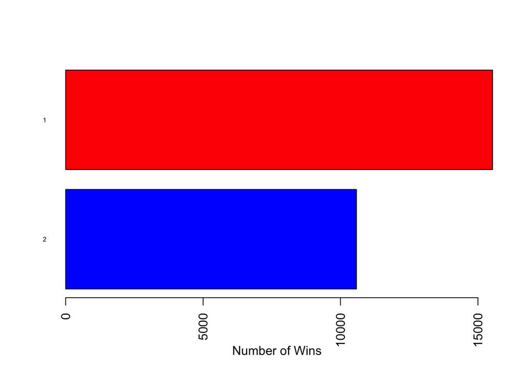

```r
> colors = c("blue", "red")
> colors2 = c("red", "blue")
> tb = sort(table(dat[dat$firstBlood == "1",]$winner))
> barplot(tb,horiz = T,las=2, cex.names = 0.5, xlab="Number of Wins", col = colors)
```

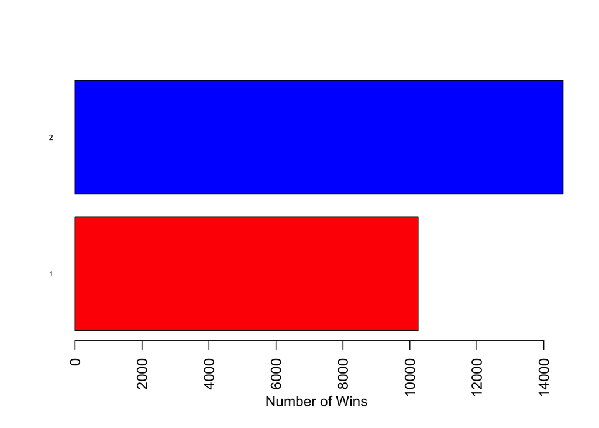

```r
> tb = sort(table(dat[dat$firstBlood == "2",]$winner))
> barplot(tb,horiz = T,las=2, cex.names = 0.5, xlab="Number of Wins", col = colors2)
```

Using these two bar plots we found that teams that had been able to secure first blood won 59% of the games that were played. This is without influence from other features so then now we will check the first tower.

*First Tower*

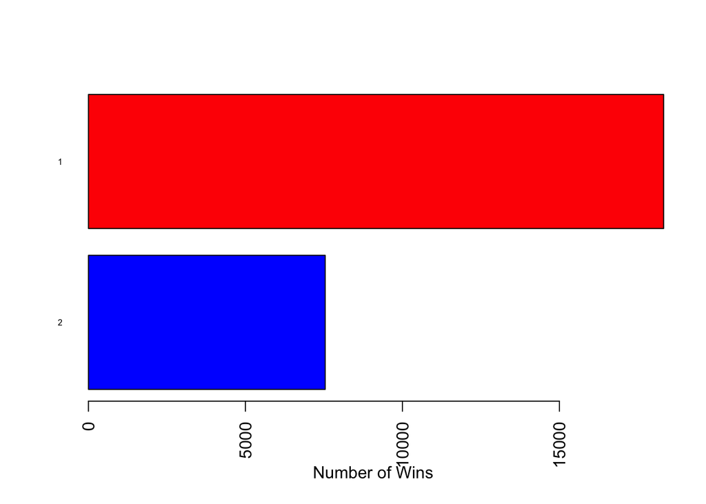

```r
> tb = sort(table(dat[dat$firstTower == "1",]$winner))
> barplot(tb,horiz = T,las=2, cex.names = 0.5, xlab="Number of Wins", col = colors)
```

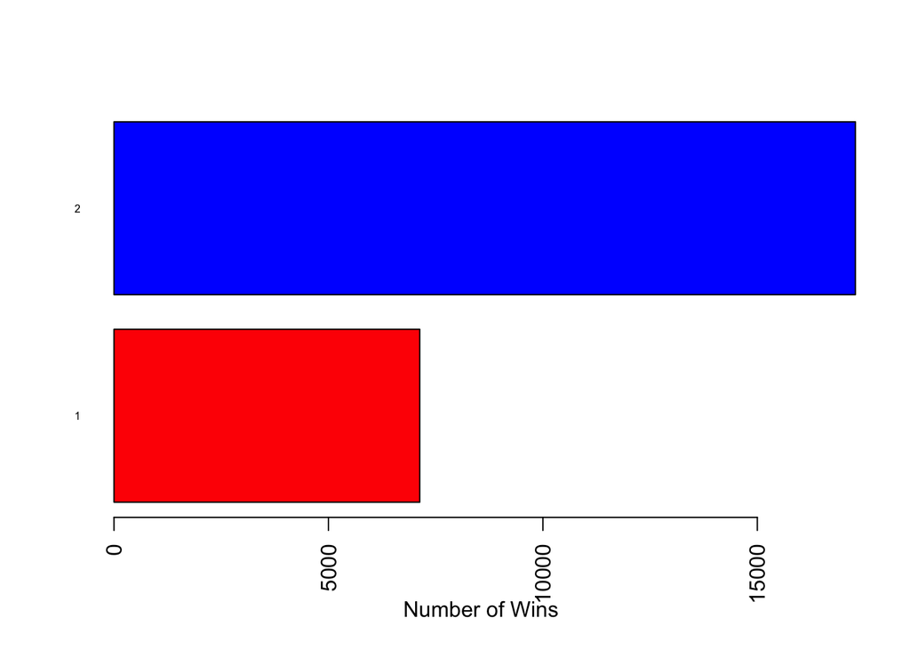

```r
> tb = sort(table(dat[dat$firstTower == "2",]$winner))
> barplot(tb,horiz = T,las=2, cex.names = 0.5, xlab="Number of Wins", col = colors2)
```

Next we tested the first tower win rate and it is significantly larger than the first blood rates, increasing to a 70% win rate for teams that were able to collect the first tower gold. This makes a lot of sense because if a team takes that tower they now have tempo and can move to another part of the map to take another tower.

*First Blood and First Tower*

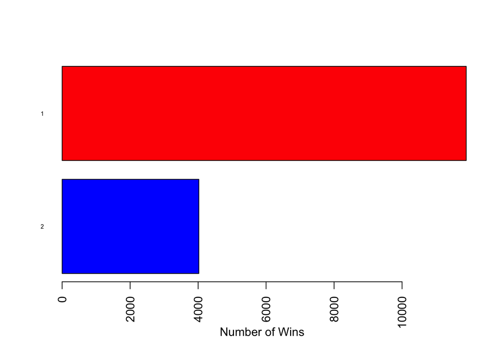

```r
> tb = sort(table(dat[dat$firstBlood == "1" & dat$firstTower == "1",]$winner))
> barplot(tb,horiz = T,las=2, cex.names = 0.5, xlab="Number of Wins", col = colors)
```

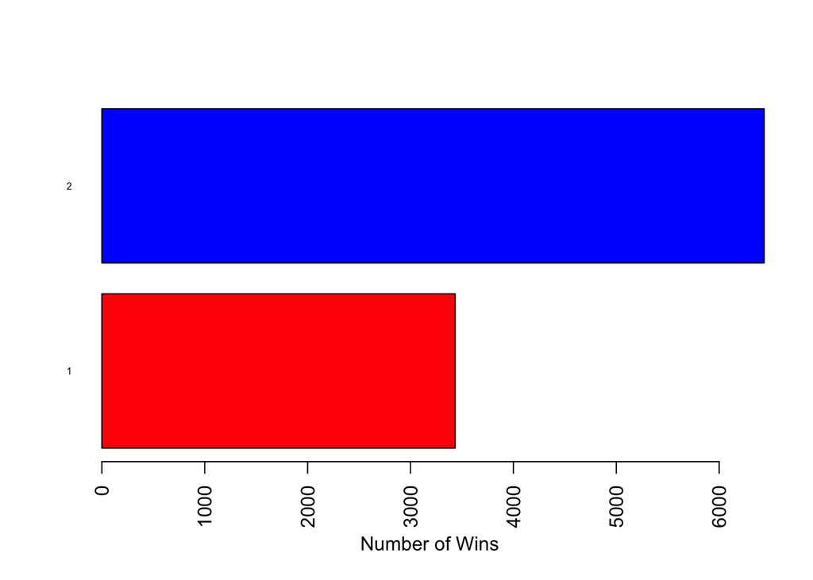

```r
> tb = sort(table(dat[dat$firstBlood == "1" & dat$firstTower == "2",]$winner))
> barplot(tb,horiz = T,las=2, cex.names = 0.5, xlab="Number of Wins", col = colors2)
```

Now if we combine the two features we increase the win percentage to 75%. It seems underwhelming compared to the difference with first tower and first blood. However, league is a team game are there are many more things that can influence the game, one of those being the player which we cannot account for.

*Histograms showing which team got what objective the most*

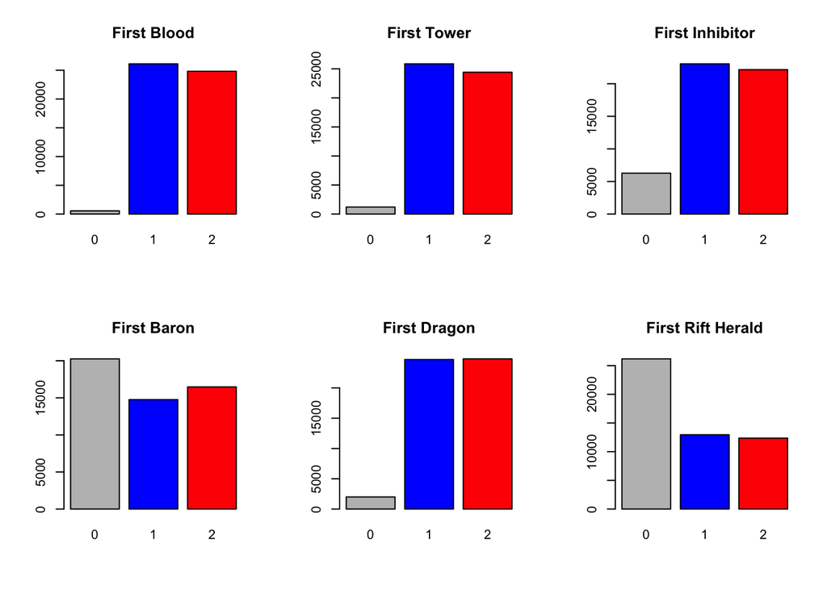

```r
> par(mfrow=c(2,3))
> colors = c("grey", "blue", "red")
> barplot(table(dat$firstBlood), main="First Blood", col=colors)
> barplot(table(dat$firstTower), main="First Tower", col=colors)
> barplot(table(dat$firstInhibitor), main="First Inhibitor", col=colors)
> barplot(table(dat$firstBaron), main="First Baron", col=colors)
> barplot(table(dat$firstDragon), main="First Dragon", col=colors)
> barplot(table(dat$firstRiftHerald), main="First Rift Herald", col=colors)
```

The graphs above show that the team that gets the first blood, first tower, first inhibitor and the herald is usually the blue team. For some reason it appears that blue side of the map has a natural advantage because it is easier to look bottom-left to top-right than it is to look top-right to bottom-left. When it comes to getting first baron, it appears that the red side usually gets it, One reason for this is because there is something called a blasting plant that can help them sneak they baron without letting the blue side know.

#### Logistic Regression Model

```r
> tr_rows=sample(nrow(dat), 0.75 * nrow(dat))
> tr_dat = dat[tr_rows,]
> te_dat = dat[-tr_rows,]
>
> fit = glm(winner-1 ~ firstBlood + firstTower, data=tr_dat, family=binomial)
>
> y = predict(fit, newdata=te_dat, type="response")
> predicts = as.numeric(y > 0.55)
> actuals = te_dat$winner-1
> conf_mtx = table(predicts, actuals)
> conf_mtx
```

```
        actuals
predicts    0    1
       0 4663 2039
       1 1801 4370
```

```r
> rate = mean(predicts == actuals)
> round(rate, 2)
```

```
[1] 0.7
```

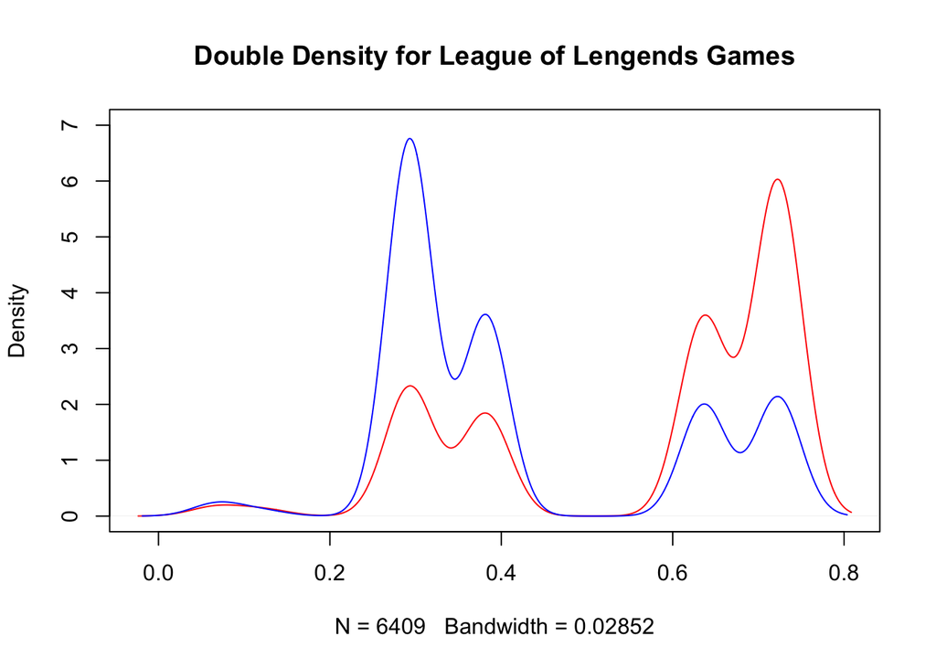

```r
> plot(density(y[actuals == 1]), col="red", main="Double Density for League of Lengends Games", ylim=c(0,7))
> lines(density(y[actuals == 0]), col="blue")
```

The double density above demostrates that if the blue team is winner, the chance for the red team is not that great, however when red team chaces up the graph shifts to there favor and the blue team is now at the disadvantage. The two plots seem to mirror each other with the blue curve being slight bigger because of the natural advantage mentioned before.

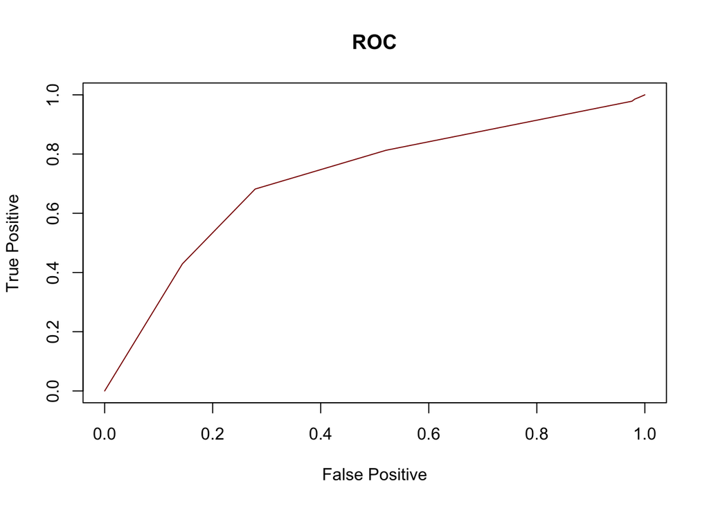

```r
> prec_recall_summary = function(predicts, actuals) {
+   thresh = seq(0, 1, length.out=65)
+   prec_rec = data.frame()
+   actuals = factor(as.numeric(actuals))
+   for (th in thresh) {
+     predicts = factor(as.numeric(y >= th), levels=c("0","1"))
+     prec_rec = rbind(prec_rec, as.vector(table(predicts, actuals)))
+   }
+   names(prec_rec) = c("TN", "FP", "FN", "TP")
+   prec_rec$precision = prec_rec$TP/(prec_rec$TP + prec_rec$FP)
+   prec_rec$recall    = prec_rec$TP/(prec_rec$TP + prec_rec$FN)
+   prec_rec$false_pos = prec_rec$FP/(prec_rec$FP + prec_rec$TN)
+   prec_rec$true_pos = prec_rec$TP/(prec_rec$TP + prec_rec$FN)
+   return(prec_rec)
+ }
> prec_rec1 = prec_recall_summary(predicts, actuals)
>
> plot(prec_rec1$true_pos ~ prec_rec1$false_pos, xlab="False Positive", ylab="True Positive", type="l", col="red4", main="ROC")
```

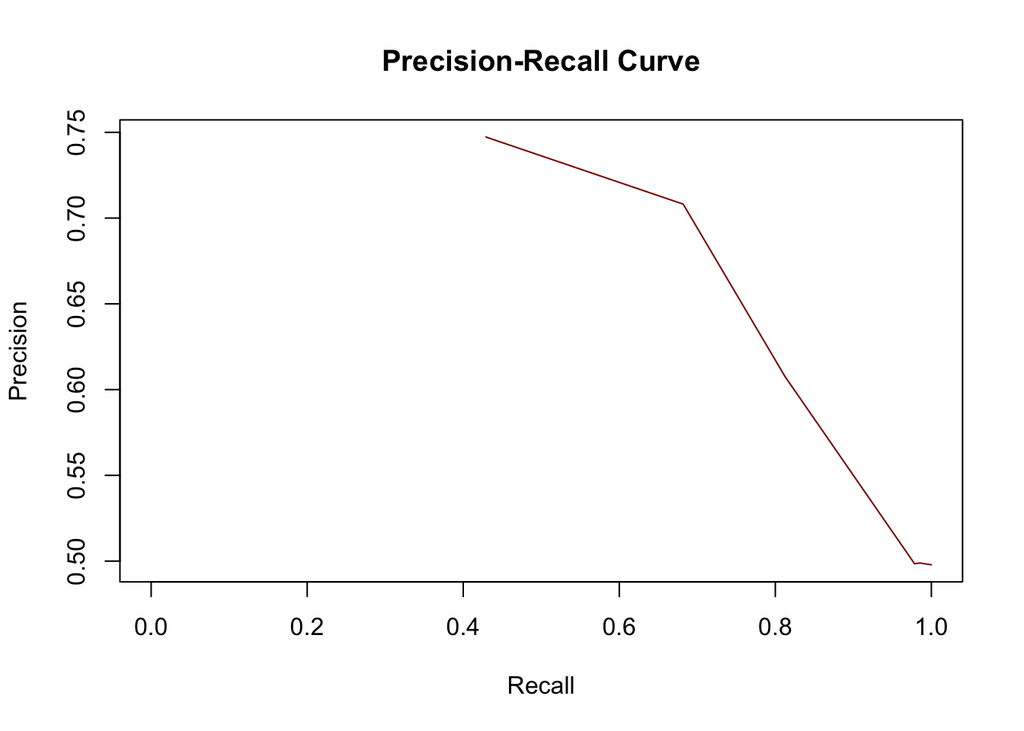

```r
> plot(prec_rec1$precision ~ prec_rec1$recall, xlab="Recall", ylab="Precision", type="l", col="red4", main="Precision-Recall Curve")
```

#### Classification Decision Tree

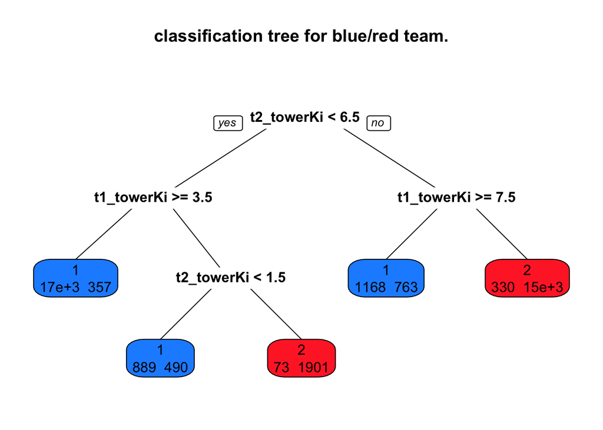

```r
> fit = rpart(winner ~ ., data=tr_dat, method="class")
> prp(fit, extra=1, varlen=-10, main="classification tree for blue/red team.", box.col=c("dodgerblue", "firebrick1")[fit$frame$yval])
```

```r
> predicted = predict(fit, te_dat, type="class")
> actual = te_dat$winner
> table(actual, predicted)
```

```
      predicted
actual    1    2
     1 6345  119
     2  552 5857
```

```r
> mean(actual == predicted)
```

```
[1] 0.9478754
```

Using this decision tree, we are able to find out which team won depending on the number of tower kills. There seems to be a consistent pattern with this because taking towers gives a significant amount of gold and that gold can be used to help the team get further ahead.

#### Assessing the Decision Tree

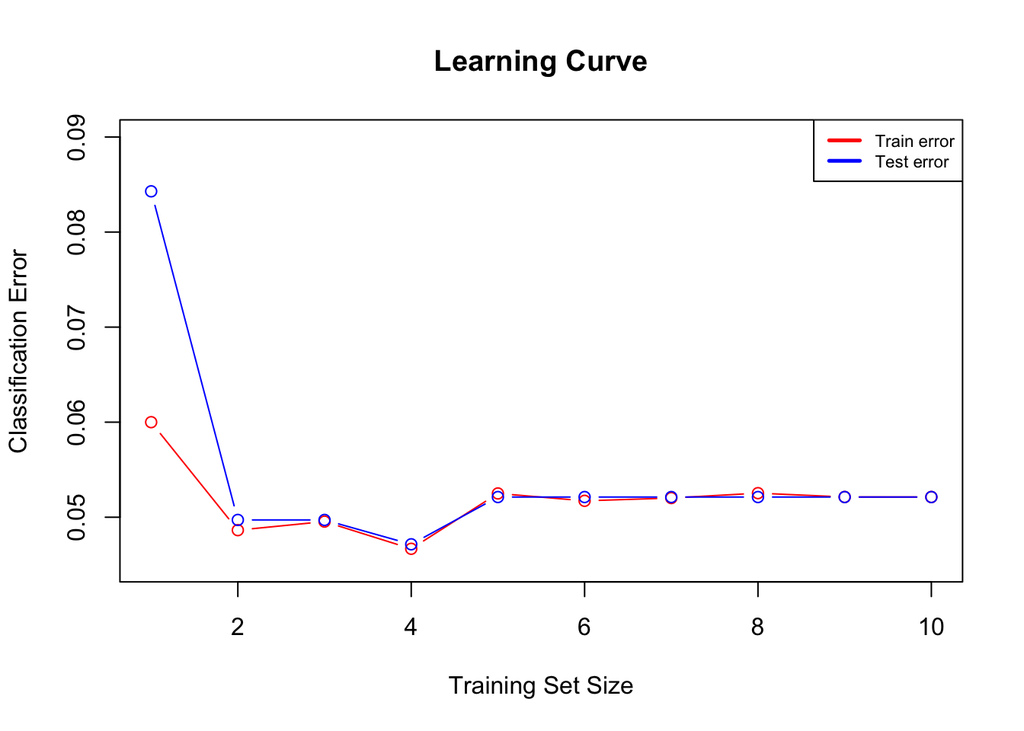

```r
> te_errs = c()
> tr_errs = c()
> te_actual = te_dat$winner
> tr_sizes = seq(100, nrow(tr_dat), length.out=10)
>  for (tr_size in tr_sizes) {
+    tr_dat1 = tr_dat[1:tr_size,]
+    tr_actual = tr_dat1$winner
+    fit = rpart(winner ~ ., data=tr_dat1,method="class")
+
+  #error on training set
+    tr_predicted = predict(fit, tr_dat1, type="class")
+    err = mean(tr_actual != tr_predicted)
+    tr_errs = c(tr_errs, err)
+    table(tr_actual, tr_predicted)
+
+  # error on test set
+    te_predicted = predict(fit, te_dat, type="class")
+    err = mean(te_actual != te_predicted)
+    te_errs = c(te_errs, err)
+    table(te_actual, te_predicted)
+  }
>  # Plot learning curve here
>  plot(tr_errs, type="b", col="red", xlab="Training Set Size", ylab="Classification Error", main=paste("Learning Curve"), ylim=c(.045,.09))
>  lines(te_errs, type = "b", col = "blue")
>  legend('topright', c("Train error", "Test error"), lty = c(1,1), lwd = c(2.5, 2.5), col = c("red", "blue"), cex=0.7)
```

Studying this learning curve shows that out lines are extremely close together, this means that we have a lot of bias. We can try and fix this by getting more features or trying to derive better features from the current data set that we have, however, obtaining more data will not help us with this.

## Project Conclusion

Each feature is very important on deciding who wins the game and from a statistical stand point it looks like first tower and the influence it can bring to the map is very important. However, it seems as we cannot always predict a winner of the game because we cannot take into account the most unstable factor, that being the player themselves.